# SimCRC: Chilean calibration results

v0.15.0.901 · run 20261111.2051

SimCRC team

2026-11-11

## Our approach: keep the validated US model

Because we don’t have Chilean screening trial to validate the Chilean model, we take as much as possible from the US model, which has been validated, and change only what the Chilean targets clearly show is different.

In the natural history we change just two things, and we feel that both can be defended from the targets:

- **Slower cancer onset.** Chile and the US have about the same number of adenomas, and a similar adenoma size distribution, but Chile has much less colorectal cancer. Slower adenoma growth could also make less cancer, but we would expect to see more small adenomas if this was the case. So we assume adenomas turn into cancer more slowly in Chile.
- **Slower symptom detection** (less certain). More Chilean cancers are found at stage 3 or 4. Our hypothesis, after discussing with Nicolás, is that a known backlog of colonoscopies for people with symptoms delays diagnosis in Chile. This seems like a reasonable explanation, but not the only one.

Everything else (adenoma onset, adenoma growth and how cancers progress before diagnosis) comes from the US posterior.

## What changes from the US, and why

| Model part | Chilean model | Why |
| --- | --- | --- |
| Background mortality | Chile 2017 life table | Deaths from other causes are specific to the Chilean population |
| Adenoma onset and growth | **Same as US** (middle 95% of the US posterior) | The US model is validated; Chilean adenoma prevalence is close to what the US model gives |
| Cancer onset | **Changed:** slower than the US | About the same number and size of adenomas, but much less CRC |
| Preclinical progression | **Same as US** (middle 95% of the US posterior) | How cancer grows before diagnosis is biology; we assume it is the same in both countries |
| Symptom detection | **Changed:** slower than the US | We assume cancers are found at later stages in Chile because there is a known backlog of colonoscopies for symptom detection |
| CRC survival | **Adjusted:** a more recent relative survival year | Fits a Chilean estimate of 5-year overall survival |

## Adapting SimCRC to Chile

1. Background mortality
2. Adenoma prevalence
3. CRC incidence
4. Stage at diagnosis
5. CRC survival

## Adapting SimCRC to Chile: background mortality

1. **Background mortality**
2. Adenoma prevalence
3. CRC incidence
4. Stage at diagnosis
5. CRC survival

## Adapting SimCRC to Chile: adenoma prevalence

1. Background mortality
2. **Adenoma prevalence**
3. CRC incidence
4. Stage at diagnosis
5. CRC survival

## Adenoma prevalence: Chile vs the US model

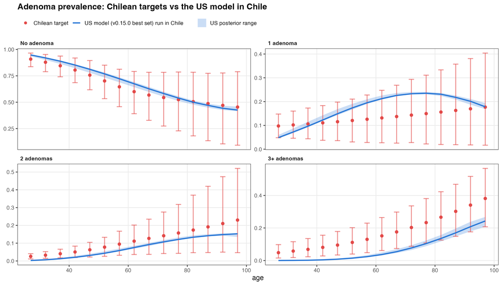

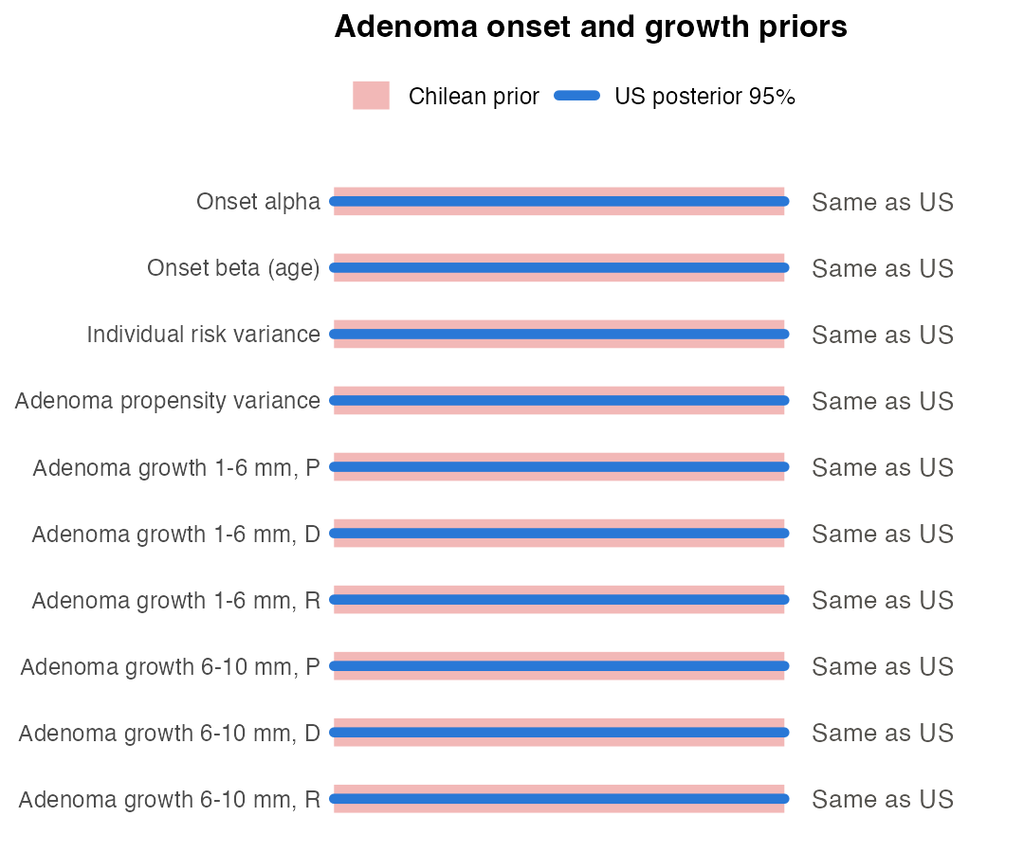

**No change.** The US model run in Chile stays inside the Chilean bounds for no adenoma and 1 adenoma at every age. It gives fewer people with **3+ adenomas** (below the bounds until about age 80) and slightly fewer with 2 adenomas before 40. We keep the **US posterior** for adenoma onset and growth and accept this gap.

## Adenoma size: Chile vs the US model

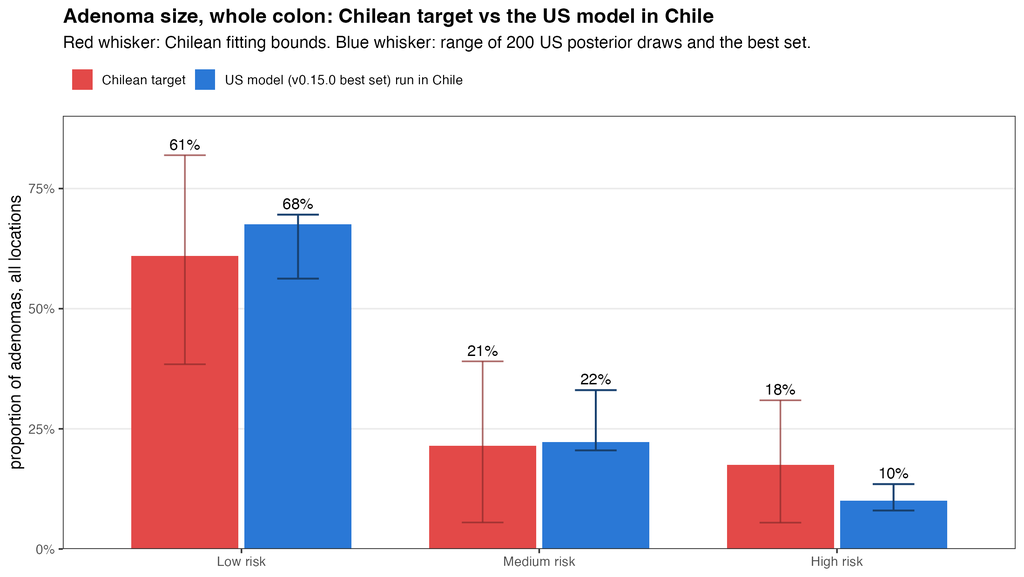

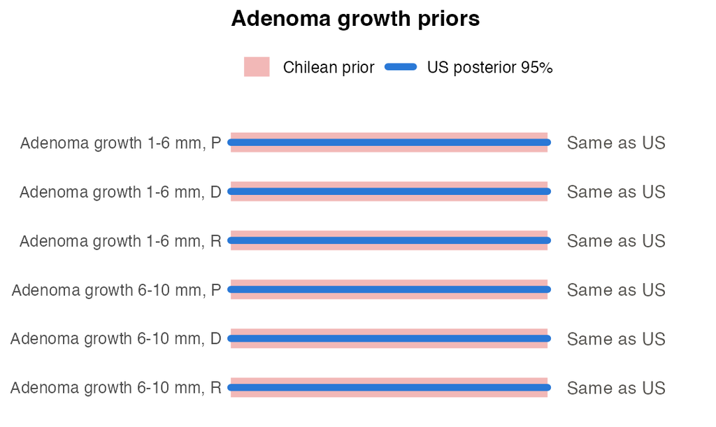

**No change.** The Chilean size target is **one value for the whole colon**, so we compare the whole colon. The US model stays inside the Chilean bounds for all three size classes. We keep the **US growth**, and with it the US differences in size by location, rather than assume size is the same everywhere.

## Adapting SimCRC to Chile: CRC incidence

1. Background mortality
2. Adenoma prevalence
3. **CRC incidence**
4. Stage at diagnosis
5. CRC survival

## CRC incidence: Chile vs the US model

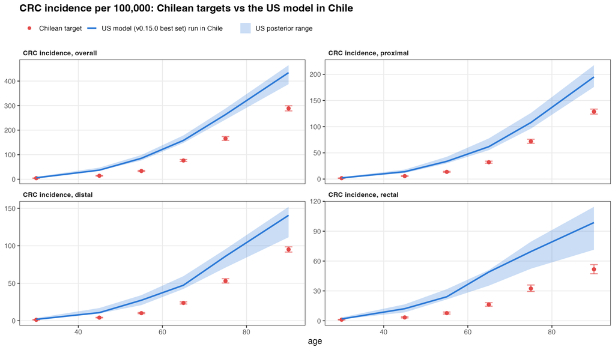

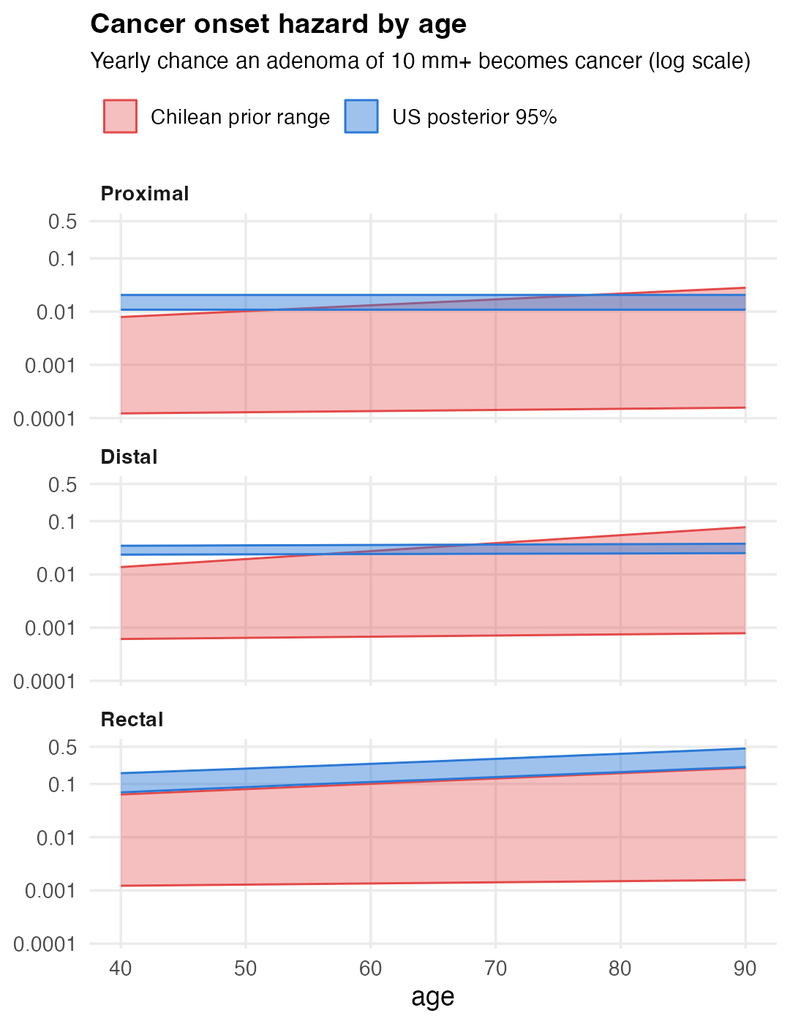

**Change: slower cancer onset.** With about the same adenomas, the US model gives Chile **1.5–2.6 times** the observed incidence. Chilean cancer onset rates are set below the US.

## Adapting SimCRC to Chile: stage at diagnosis

1. Background mortality
2. Adenoma prevalence
3. CRC incidence
4. **Stage at diagnosis**
5. CRC survival

## Stage at diagnosis: Chile vs the US model

Proportion of diagnosed cancers by stage: Chilean targets and the US best set run in Chile.

| Stage at diagnosis | Proximal: Chile | Proximal: US model | Distal: Chile | Distal: US model | Rectal: Chile | Rectal: US model |
| --- | --- | --- | --- | --- | --- | --- |
| Stage 1 | 7% | 10% | 7% | 17% | 7% | 25% |
| Stage 2 | 26% | 41% | 26% | 35% | 20% | 27% |
| Stage 3 | 34% | 26% | 32% | 21% | 44% | 24% |
| Stage 4 | 33% | 23% | 35% | 27% | 29% | 24% |

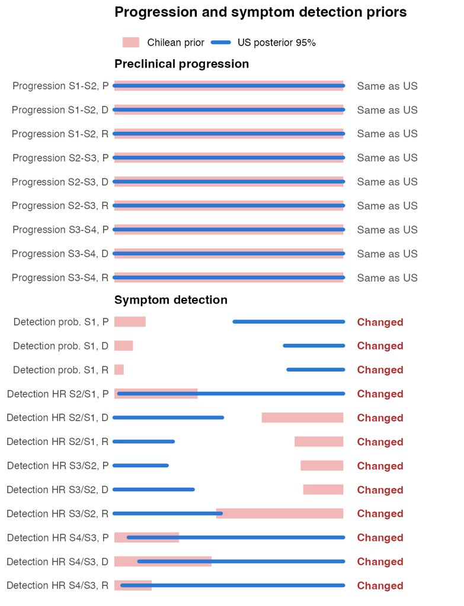

**Change: slower symptom detection only.** The US model finds far more Chilean cancers at stage 1 (10–25% vs 7%) and too few at stage 3. We could change progression, symptom detection or both. We change **symptom detection only**, so the natural history stays the US one. Progression before diagnosis keeps the **US posterior**.

## Adapting SimCRC to Chile: CRC survival

1. Background mortality
2. Adenoma prevalence
3. CRC incidence
4. Stage at diagnosis
5. **CRC survival**

## CRC survival

- We found an estimate of **5-year overall survival** for Chilean CRC patients.
- We compared it with model results under different relative survival assumptions.
- Assuming a **more recent relative survival year** fit the Chilean estimate better, so we use it.

## Chile best set vs Chilean targets: incidence and prevalence

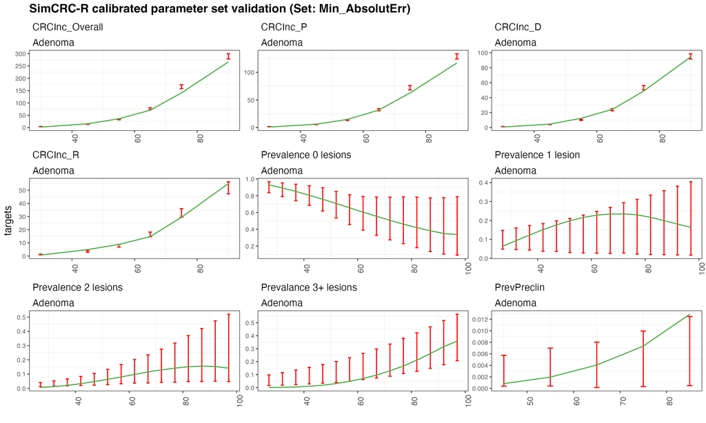

Chilean best set. Incidence per 100,000; prevalence as proportions. Red: Chilean targets and fitting bounds. Green: model.

## Chile best set vs Chilean targets: stage and size

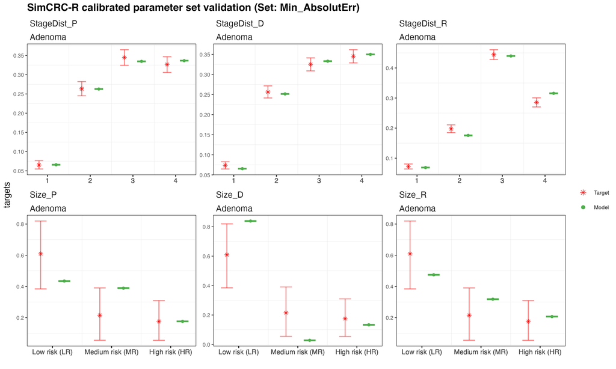

Chilean best set. Stage at diagnosis and adenoma size, as proportions. Red: Chilean targets and fitting bounds. Green: model.

## Dwell and sojourn time

Both best sets in the same Chilean population, with the Chilean life table, so the difference comes from the natural history only.

| Mean time (years) | US best set | Chile best set |  |
| --- | --- | --- | --- |
| Adenoma dwell (adenoma onset to preclinical cancer) | 26.4 | 29.3 | +2.9 |
| Sojourn (preclinical cancer to symptom detection) | 3.6 | 4.4 | +0.8 |
| Total dwell (adenoma onset to symptom detection) | 30.0 | 33.7 | +3.7 |

- **Adenoma dwell is about 3 years longer** in Chile, because we assume slower **cancer onset**.
- **Sojourn is less than 1 year longer**, because cancer **progression is the same as the US** and only **symptom detection** is slower. A slower detection rate means that cancers take longer to be detected, which means more cancers are detected at a more advanced stage.

## Symptom detection rates, best sets

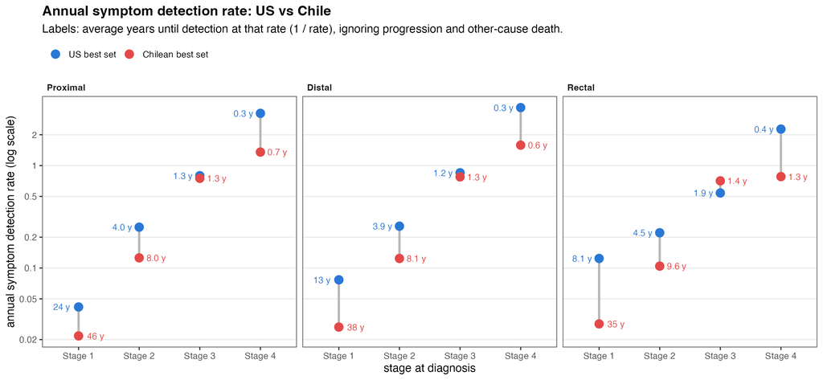

**Annual rate** at which an undiagnosed (preclinical) CRC is detected because of symptoms, in the absence of screening and of death from other causes.